# Do females perform better than males in school?

## Do females perform better than males in school?

This analysis attempts to answer.Do females perform better than males in school given all other factors are the same? And what is the most influential factor that decides how well a student performs.The hypothesis presesnted is the average performance of female students differ from the average perfromace of male students.

This project uses the Student Performance Data Set (http://archive.ics.uci.edu/ml/datasets/Student+Performance) from the UCI machine learning repositiry. I to use R to wrangle the data organize and create new features. I also have a summary table summarizing key statistics. A boxplot is shown for my visulization.

```r
library(tidyverse)
library(broom)
```

## Load Data

```r
dat1 <- read.table('https://raw.githubusercontent.com/TeddTech/student_data/master/student-mat.csv',sep=";",header=TRUE)

dat2 <- dat1 %>% mutate(average_grade = (G1+ G2+ G3)/3)
dat2
```

[output not shown]

[output cut: 1569 more lines]

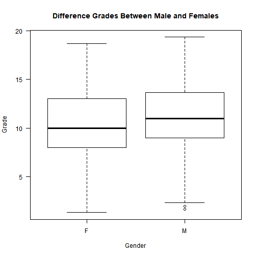

```r
boxplot(dat2$average_grade~dat2$sex,
        las=1, ylab="Grade", xlab="Gender", main="Difference Grades Between Male and Females")
```

```r
table(dat2$sex)
```

```
##
##   F   M
## 208 187
```

```r
(ttest <- t.test(dat2$average_grade~dat2$sex, paired=F, var.eq=T))
```

```
##
##  Two Sample t-test
##
## data:  dat2$average_grade by dat2$sex
## t = -2.015, df = 393, p-value = 0.04459
## alternative hypothesis: true difference in means is not equal to 0
## 95 percent confidence interval:
##  -1.4773516 -0.0181749
## sample estimates:
## mean in group F mean in group M
##        10.32532        11.07308
```

```r
tidy(ttest)
```

```
##   estimate1 estimate2 statistic    p.value parameter  conf.low  conf.high
## 1  10.32532  11.07308 -2.014994 0.04458573       393 -1.477352 -0.0181749
##               method alternative
## 1  Two Sample t-test   two.sided
```